# Risk Factor Analysis

## Outcome Variable

**Outcome Variable:** sstunted

## Predictor Variables

**Intervention Variable:** exclfeed6

**Adjustment Set:**

- arm
- sex
- brthmon
- W_mage
- meducyrs
- feducyrs
- hhwealth_quart
- hfoodsec
- W_mhtcm
- W_mwtkg
- W_mbmi
- vagbrth
- W_gagebrth
- W_birthwt
- W_birthlen
- W_nrooms
- W_nchldlt5
- month
- W_parity
- impfloor
- impsan
- safeh20
- delta_W_mage
- delta_meducyrs
- delta_feducyrs
- delta_hhwealth_quart
- delta_hfoodsec
- delta_W_mhtcm
- delta_W_mwtkg
- delta_W_mbmi
- delta_vagbrth
- delta_W_gagebrth
- delta_W_birthwt
- delta_W_birthlen
- delta_W_nrooms
- delta_W_nchldlt5
- delta_month
- delta_W_parity
- delta_impfloor
- delta_impsan
- delta_safeh20

## Stratifying Variables

The analysis was stratified on these variable(s):

- agecat
- studyid
- country

## Data Summary

| agecat | studyid | country | exclfeed6 | sstunted | n_cell | n |
| --- | --- | --- | --- | --- | --- | --- |
| Birth | ki0047075b-MAL-ED | BANGLADESH | 1 | 0 | 31 | 205 |
| Birth | ki0047075b-MAL-ED | BANGLADESH | 1 | 1 | 0 | 205 |
| Birth | ki0047075b-MAL-ED | BANGLADESH | 0 | 0 | 169 | 205 |
| Birth | ki0047075b-MAL-ED | BANGLADESH | 0 | 1 | 5 | 205 |
| Birth | ki0047075b-MAL-ED | BRAZIL | 1 | 0 | 1 | 60 |
| Birth | ki0047075b-MAL-ED | BRAZIL | 1 | 1 | 1 | 60 |
| Birth | ki0047075b-MAL-ED | BRAZIL | 0 | 0 | 56 | 60 |
| Birth | ki0047075b-MAL-ED | BRAZIL | 0 | 1 | 2 | 60 |
| Birth | ki0047075b-MAL-ED | INDIA | 1 | 0 | 1 | 39 |
| Birth | ki0047075b-MAL-ED | INDIA | 1 | 1 | 0 | 39 |
| Birth | ki0047075b-MAL-ED | INDIA | 0 | 0 | 36 | 39 |
| Birth | ki0047075b-MAL-ED | INDIA | 0 | 1 | 2 | 39 |
| Birth | ki0047075b-MAL-ED | NEPAL | 1 | 0 | 2 | 24 |
| Birth | ki0047075b-MAL-ED | NEPAL | 1 | 1 | 0 | 24 |
| Birth | ki0047075b-MAL-ED | NEPAL | 0 | 0 | 21 | 24 |
| Birth | ki0047075b-MAL-ED | NEPAL | 0 | 1 | 1 | 24 |
| Birth | ki0047075b-MAL-ED | PERU | 1 | 0 | 2 | 213 |
| Birth | ki0047075b-MAL-ED | PERU | 1 | 1 | 0 | 213 |
| Birth | ki0047075b-MAL-ED | PERU | 0 | 0 | 207 | 213 |
| Birth | ki0047075b-MAL-ED | PERU | 0 | 1 | 4 | 213 |
| Birth | ki0047075b-MAL-ED | SOUTH AFRICA | 1 | 0 | 0 | 91 |
| Birth | ki0047075b-MAL-ED | SOUTH AFRICA | 1 | 1 | 0 | 91 |
| Birth | ki0047075b-MAL-ED | SOUTH AFRICA | 0 | 0 | 90 | 91 |
| Birth | ki0047075b-MAL-ED | SOUTH AFRICA | 0 | 1 | 1 | 91 |
| Birth | ki0047075b-MAL-ED | TANZANIA, UNITED REPUBLIC OF | 1 | 0 | 0 | 113 |
| Birth | ki0047075b-MAL-ED | TANZANIA, UNITED REPUBLIC OF | 1 | 1 | 0 | 113 |
| Birth | ki0047075b-MAL-ED | TANZANIA, UNITED REPUBLIC OF | 0 | 0 | 105 | 113 |
| Birth | ki0047075b-MAL-ED | TANZANIA, UNITED REPUBLIC OF | 0 | 1 | 8 | 113 |
| Birth | ki1000108-CMC-V-BCS-2002 | INDIA | 1 | 0 | 7 | 7 |
| Birth | ki1000108-CMC-V-BCS-2002 | INDIA | 1 | 1 | 0 | 7 |

[output cut: 170 more lines]

The following strata were considered:

- agecat: 24 months, studyid: ki0047075b-MAL-ED, country: BANGLADESH
- agecat: 24 months, studyid: ki0047075b-MAL-ED, country: BRAZIL
- agecat: 24 months, studyid: ki0047075b-MAL-ED, country: INDIA
- agecat: 24 months, studyid: ki0047075b-MAL-ED, country: NEPAL
- agecat: 24 months, studyid: ki0047075b-MAL-ED, country: PERU
- agecat: 24 months, studyid: ki0047075b-MAL-ED, country: SOUTH AFRICA
- agecat: 24 months, studyid: ki0047075b-MAL-ED, country: TANZANIA, UNITED REPUBLIC OF
- agecat: 24 months, studyid: ki1000108-CMC-V-BCS-2002, country: INDIA
- agecat: 24 months, studyid: ki1000108-IRC, country: INDIA
- agecat: 24 months, studyid: ki1000109-EE, country: PAKISTAN
- agecat: 24 months, studyid: ki1017093b-PROVIDE, country: BANGLADESH
- agecat: 24 months, studyid: ki1101329-Keneba, country: GAMBIA
- agecat: 24 months, studyid: ki1113344-GMS-Nepal, country: NEPAL
- agecat: 24 months, studyid: ki1148112-LCNI-5, country: MALAWI
- agecat: 24 months, studyid: kiGH5241-JiVitA-3, country: BANGLADESH
- agecat: 24 months, studyid: kiGH5241-JiVitA-4, country: BANGLADESH
- agecat: 6 months, studyid: ki0047075b-MAL-ED, country: BANGLADESH
- agecat: 6 months, studyid: ki0047075b-MAL-ED, country: BRAZIL
- agecat: 6 months, studyid: ki0047075b-MAL-ED, country: INDIA
- agecat: 6 months, studyid: ki0047075b-MAL-ED, country: NEPAL
- agecat: 6 months, studyid: ki0047075b-MAL-ED, country: PERU
- agecat: 6 months, studyid: ki0047075b-MAL-ED, country: SOUTH AFRICA
- agecat: 6 months, studyid: ki0047075b-MAL-ED, country: TANZANIA, UNITED REPUBLIC OF
- agecat: 6 months, studyid: ki1000108-CMC-V-BCS-2002, country: INDIA
- agecat: 6 months, studyid: ki1000108-IRC, country: INDIA
- agecat: 6 months, studyid: ki1000109-EE, country: PAKISTAN
- agecat: 6 months, studyid: ki1000304b-SAS-CompFeed, country: INDIA
- agecat: 6 months, studyid: ki1000304b-SAS-FoodSuppl, country: INDIA
- agecat: 6 months, studyid: ki1017093b-PROVIDE, country: BANGLADESH
- agecat: 6 months, studyid: ki1101329-Keneba, country: GAMBIA
- agecat: 6 months, studyid: ki1113344-GMS-Nepal, country: NEPAL
- agecat: 6 months, studyid: ki1148112-LCNI-5, country: MALAWI
- agecat: 6 months, studyid: kiGH5241-JiVitA-3, country: BANGLADESH
- agecat: 6 months, studyid: kiGH5241-JiVitA-4, country: BANGLADESH
- agecat: Birth, studyid: ki0047075b-MAL-ED, country: BANGLADESH
- agecat: Birth, studyid: ki0047075b-MAL-ED, country: BRAZIL
- agecat: Birth, studyid: ki0047075b-MAL-ED, country: INDIA
- agecat: Birth, studyid: ki0047075b-MAL-ED, country: NEPAL
- agecat: Birth, studyid: ki0047075b-MAL-ED, country: PERU
- agecat: Birth, studyid: ki0047075b-MAL-ED, country: SOUTH AFRICA
- agecat: Birth, studyid: ki0047075b-MAL-ED, country: TANZANIA, UNITED REPUBLIC OF
- agecat: Birth, studyid: ki1000108-CMC-V-BCS-2002, country: INDIA
- agecat: Birth, studyid: ki1000108-IRC, country: INDIA
- agecat: Birth, studyid: ki1000109-EE, country: PAKISTAN
- agecat: Birth, studyid: ki1000304b-SAS-CompFeed, country: INDIA
- agecat: Birth, studyid: ki1017093b-PROVIDE, country: BANGLADESH
- agecat: Birth, studyid: ki1101329-Keneba, country: GAMBIA
- agecat: Birth, studyid: ki1113344-GMS-Nepal, country: NEPAL
- agecat: Birth, studyid: kiGH5241-JiVitA-3, country: BANGLADESH
- agecat: Birth, studyid: kiGH5241-JiVitA-4, country: BANGLADESH

### Dropped Strata

Some strata were dropped due to rare outcomes:

- agecat: Birth, studyid: ki0047075b-MAL-ED, country: BANGLADESH
- agecat: Birth, studyid: ki0047075b-MAL-ED, country: BRAZIL
- agecat: Birth, studyid: ki0047075b-MAL-ED, country: INDIA
- agecat: Birth, studyid: ki0047075b-MAL-ED, country: NEPAL
- agecat: Birth, studyid: ki0047075b-MAL-ED, country: PERU
- agecat: Birth, studyid: ki0047075b-MAL-ED, country: SOUTH AFRICA
- agecat: Birth, studyid: ki0047075b-MAL-ED, country: TANZANIA, UNITED REPUBLIC OF
- agecat: Birth, studyid: ki1000108-CMC-V-BCS-2002, country: INDIA
- agecat: Birth, studyid: ki1000108-IRC, country: INDIA
- agecat: Birth, studyid: ki1000109-EE, country: PAKISTAN
- agecat: Birth, studyid: ki1000304b-SAS-CompFeed, country: INDIA
- agecat: Birth, studyid: ki1017093b-PROVIDE, country: BANGLADESH
- agecat: 6 months, studyid: ki0047075b-MAL-ED, country: BANGLADESH
- agecat: 6 months, studyid: ki0047075b-MAL-ED, country: BRAZIL
- agecat: 6 months, studyid: ki0047075b-MAL-ED, country: INDIA
- agecat: 6 months, studyid: ki0047075b-MAL-ED, country: NEPAL
- agecat: 6 months, studyid: ki0047075b-MAL-ED, country: PERU
- agecat: 6 months, studyid: ki0047075b-MAL-ED, country: SOUTH AFRICA
- agecat: 6 months, studyid: ki0047075b-MAL-ED, country: TANZANIA, UNITED REPUBLIC OF
- agecat: 6 months, studyid: ki1000108-CMC-V-BCS-2002, country: INDIA
- agecat: 6 months, studyid: ki1000108-IRC, country: INDIA
- agecat: 6 months, studyid: ki1000109-EE, country: PAKISTAN
- agecat: 6 months, studyid: ki1000304b-SAS-CompFeed, country: INDIA
- agecat: 6 months, studyid: ki1000304b-SAS-FoodSuppl, country: INDIA
- agecat: 6 months, studyid: ki1017093b-PROVIDE, country: BANGLADESH
- agecat: 6 months, studyid: ki1148112-LCNI-5, country: MALAWI
- agecat: 24 months, studyid: ki0047075b-MAL-ED, country: BRAZIL
- agecat: 24 months, studyid: ki0047075b-MAL-ED, country: INDIA
- agecat: 24 months, studyid: ki0047075b-MAL-ED, country: NEPAL
- agecat: 24 months, studyid: ki0047075b-MAL-ED, country: PERU
- agecat: 24 months, studyid: ki0047075b-MAL-ED, country: SOUTH AFRICA
- agecat: 24 months, studyid: ki0047075b-MAL-ED, country: TANZANIA, UNITED REPUBLIC OF
- agecat: 24 months, studyid: ki1000108-CMC-V-BCS-2002, country: INDIA
- agecat: 24 months, studyid: ki1000108-IRC, country: INDIA
- agecat: 24 months, studyid: ki1000109-EE, country: PAKISTAN
- agecat: 24 months, studyid: ki1148112-LCNI-5, country: MALAWI

## Methods Detail

We’re interested in the causal parameters $E[Y_a]$ for all values of $a \in \mathcal{A}$. These parameters represent the mean outcome if, possibly contrary to fact, we intervened to set all units to have $A=a$. Under the randomization and positivity assumptions, these are identified by the statistical parameters $\psi_a=E_W[E_{Y|A,W}(Y|A=a,W)]$. In addition, we’re interested in the mean of $Y$, $E[Y]$ under no intervention (the observed mean). We will estimate these parameters by using SuperLearner to fit the relevant likelihood factors – $E_{Y|A,W}(Y|A=a,W)$ and $p(A=a|W)$, and then updating our likelihood fit using a joint TMLE.

For unadjusted analyses ($W=\{\}$), initial likelihoods were estimated using Lrnr_glm to estimate the simple $E(Y|A)$ and Lrnr_mean to estimate $p(A)$. For adjusted analyses, a small library containing Lrnr_glmnet, Lrnr_xgboost, and Lrnr_mean was used.

Having estimated these parameters, we will then use the delta method to estimate relative risks and attributable risks relative to a prespecified baseline level of $A$.

# Results Detail

## Results Plots

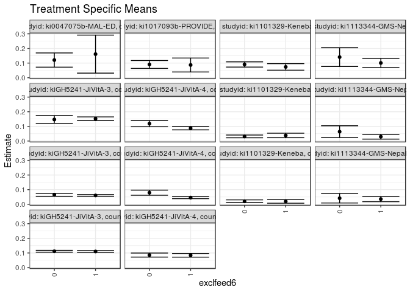

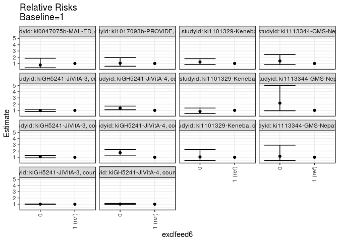

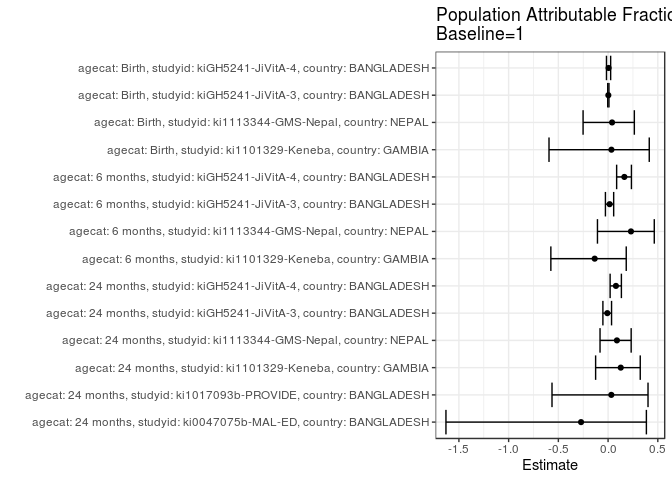

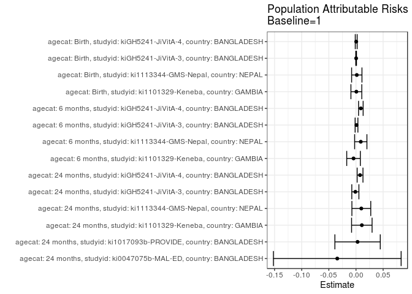

## Results Table

### Parameter: TSM

| agecat | studyid | country | intervention_level | baseline_level | estimate | ci_lower | ci_upper |
| --- | --- | --- | --- | --- | --- | --- | --- |
| Birth | ki1101329-Keneba | GAMBIA | 1 | NA | 0.0199772 | 0.0076503 | 0.0323041 |
| Birth | ki1101329-Keneba | GAMBIA | 0 | NA | 0.0208906 | 0.0115667 | 0.0302145 |
| Birth | ki1113344-GMS-Nepal | NEPAL | 1 | NA | 0.0357995 | 0.0179942 | 0.0536048 |
| Birth | ki1113344-GMS-Nepal | NEPAL | 0 | NA | 0.0416667 | 0.0089999 | 0.0743334 |
| Birth | kiGH5241-JiVitA-3 | BANGLADESH | 1 | NA | 0.1101982 | 0.1043875 | 0.1160089 |
| Birth | kiGH5241-JiVitA-3 | BANGLADESH | 0 | NA | 0.1113467 | 0.1051526 | 0.1175409 |
| Birth | kiGH5241-JiVitA-4 | BANGLADESH | 1 | NA | 0.0839224 | 0.0714247 | 0.0964200 |
| Birth | kiGH5241-JiVitA-4 | BANGLADESH | 0 | NA | 0.0856467 | 0.0718520 | 0.0994415 |
| 6 months | ki1101329-Keneba | GAMBIA | 1 | NA | 0.0380648 | 0.0226693 | 0.0534603 |
| 6 months | ki1101329-Keneba | GAMBIA | 0 | NA | 0.0315316 | 0.0220961 | 0.0409671 |
| 6 months | ki1113344-GMS-Nepal | NEPAL | 1 | NA | 0.0295567 | 0.0130676 | 0.0460457 |
| 6 months | ki1113344-GMS-Nepal | NEPAL | 0 | NA | 0.0638298 | 0.0234443 | 0.1042152 |
| 6 months | kiGH5241-JiVitA-3 | BANGLADESH | 1 | NA | 0.0605522 | 0.0549243 | 0.0661801 |
| 6 months | kiGH5241-JiVitA-3 | BANGLADESH | 0 | NA | 0.0650107 | 0.0547844 | 0.0752369 |
| 6 months | kiGH5241-JiVitA-4 | BANGLADESH | 1 | NA | 0.0458094 | 0.0386529 | 0.0529659 |
| 6 months | kiGH5241-JiVitA-4 | BANGLADESH | 0 | NA | 0.0794327 | 0.0619643 | 0.0969012 |
| 24 months | ki0047075b-MAL-ED | BANGLADESH | 1 | NA | 0.1612903 | 0.0315010 | 0.2910797 |
| 24 months | ki0047075b-MAL-ED | BANGLADESH | 0 | NA | 0.1206897 | 0.0721673 | 0.1692120 |
| 24 months | ki1017093b-PROVIDE | BANGLADESH | 1 | NA | 0.0870333 | 0.0394315 | 0.1346351 |
| 24 months | ki1017093b-PROVIDE | BANGLADESH | 0 | NA | 0.0906231 | 0.0637425 | 0.1175038 |
| 24 months | ki1101329-Keneba | GAMBIA | 1 | NA | 0.0738220 | 0.0514825 | 0.0961615 |
| 24 months | ki1101329-Keneba | GAMBIA | 0 | NA | 0.0905919 | 0.0727492 | 0.1084345 |
| 24 months | ki1113344-GMS-Nepal | NEPAL | 1 | NA | 0.1008023 | 0.0694726 | 0.1321320 |
| 24 months | ki1113344-GMS-Nepal | NEPAL | 0 | NA | 0.1408160 | 0.0767004 | 0.2049316 |
| 24 months | kiGH5241-JiVitA-3 | BANGLADESH | 1 | NA | 0.1521115 | 0.1395603 | 0.1646627 |
| 24 months | kiGH5241-JiVitA-3 | BANGLADESH | 0 | NA | 0.1471206 | 0.1204955 | 0.1737457 |
| 24 months | kiGH5241-JiVitA-4 | BANGLADESH | 1 | NA | 0.0877472 | 0.0761912 | 0.0993032 |
| 24 months | kiGH5241-JiVitA-4 | BANGLADESH | 0 | NA | 0.1187701 | 0.0973392 | 0.1402009 |

### Parameter: E(Y)

| agecat | studyid | country | intervention_level | baseline_level | estimate | ci_lower | ci_upper |
| --- | --- | --- | --- | --- | --- | --- | --- |
| Birth | ki1101329-Keneba | GAMBIA | NA | NA | 0.0206700 | 0.0132225 | 0.0281175 |
| Birth | ki1113344-GMS-Nepal | NEPAL | NA | NA | 0.0373002 | 0.0216334 | 0.0529670 |
| Birth | kiGH5241-JiVitA-3 | BANGLADESH | NA | NA | 0.1104820 | 0.1047181 | 0.1162459 |
| Birth | kiGH5241-JiVitA-4 | BANGLADESH | NA | NA | 0.0843465 | 0.0720577 | 0.0966353 |
| 6 months | ki1101329-Keneba | GAMBIA | NA | NA | 0.0335430 | 0.0254620 | 0.0416240 |
| 6 months | ki1113344-GMS-Nepal | NEPAL | NA | NA | 0.0383912 | 0.0222749 | 0.0545076 |
| 6 months | kiGH5241-JiVitA-3 | BANGLADESH | NA | NA | 0.0615089 | 0.0563485 | 0.0666694 |
| 6 months | kiGH5241-JiVitA-4 | BANGLADESH | NA | NA | 0.0547753 | 0.0477475 | 0.0618030 |
| 24 months | ki0047075b-MAL-ED | BANGLADESH | NA | NA | 0.1268293 | 0.0811633 | 0.1724952 |
| 24 months | ki1017093b-PROVIDE | BANGLADESH | NA | NA | 0.0899654 | 0.0666186 | 0.1133122 |
| 24 months | ki1101329-Keneba | GAMBIA | NA | NA | 0.0846001 | 0.0705732 | 0.0986271 |
| 24 months | ki1113344-GMS-Nepal | NEPAL | NA | NA | 0.1106383 | 0.0822491 | 0.1390275 |
| 24 months | kiGH5241-JiVitA-3 | BANGLADESH | NA | NA | 0.1509434 | 0.1390224 | 0.1628644 |
| 24 months | kiGH5241-JiVitA-4 | BANGLADESH | NA | NA | 0.0952608 | 0.0849096 | 0.1056119 |

### Parameter: RR

| agecat | studyid | country | intervention_level | baseline_level | estimate | ci_lower | ci_upper |
| --- | --- | --- | --- | --- | --- | --- | --- |
| Birth | ki1101329-Keneba | GAMBIA | 1 | 1 | 1.0000000 | 1.0000000 | 1.000000 |
| Birth | ki1101329-Keneba | GAMBIA | 0 | 1 | 1.0457222 | 0.4883045 | 2.239453 |
| Birth | ki1113344-GMS-Nepal | NEPAL | 1 | 1 | 1.0000000 | 1.0000000 | 1.000000 |
| Birth | ki1113344-GMS-Nepal | NEPAL | 0 | 1 | 1.1638889 | 0.4599272 | 2.945330 |
| Birth | kiGH5241-JiVitA-3 | BANGLADESH | 1 | 1 | 1.0000000 | 1.0000000 | 1.000000 |
| Birth | kiGH5241-JiVitA-3 | BANGLADESH | 0 | 1 | 1.0104226 | 0.9830852 | 1.038520 |
| Birth | kiGH5241-JiVitA-4 | BANGLADESH | 1 | 1 | 1.0000000 | 1.0000000 | 1.000000 |
| Birth | kiGH5241-JiVitA-4 | BANGLADESH | 0 | 1 | 1.0205471 | 0.9241729 | 1.126971 |
| 6 months | ki1101329-Keneba | GAMBIA | 1 | 1 | 1.0000000 | 1.0000000 | 1.000000 |
| 6 months | ki1101329-Keneba | GAMBIA | 0 | 1 | 0.8283674 | 0.5010473 | 1.369516 |
| 6 months | ki1113344-GMS-Nepal | NEPAL | 1 | 1 | 1.0000000 | 1.0000000 | 1.000000 |
| 6 months | ki1113344-GMS-Nepal | NEPAL | 0 | 1 | 2.1595745 | 0.9290246 | 5.020063 |
| 6 months | kiGH5241-JiVitA-3 | BANGLADESH | 1 | 1 | 1.0000000 | 1.0000000 | 1.000000 |
| 6 months | kiGH5241-JiVitA-3 | BANGLADESH | 0 | 1 | 1.0736307 | 0.9023595 | 1.277410 |
| 6 months | kiGH5241-JiVitA-4 | BANGLADESH | 1 | 1 | 1.0000000 | 1.0000000 | 1.000000 |
| 6 months | kiGH5241-JiVitA-4 | BANGLADESH | 0 | 1 | 1.7339835 | 1.3343284 | 2.253343 |
| 24 months | ki0047075b-MAL-ED | BANGLADESH | 1 | 1 | 1.0000000 | 1.0000000 | 1.000000 |
| 24 months | ki0047075b-MAL-ED | BANGLADESH | 0 | 1 | 0.7482759 | 0.3043666 | 1.839613 |
| 24 months | ki1017093b-PROVIDE | BANGLADESH | 1 | 1 | 1.0000000 | 1.0000000 | 1.000000 |
| 24 months | ki1017093b-PROVIDE | BANGLADESH | 0 | 1 | 1.0412463 | 0.5586693 | 1.940672 |
| 24 months | ki1101329-Keneba | GAMBIA | 1 | 1 | 1.0000000 | 1.0000000 | 1.000000 |
| 24 months | ki1101329-Keneba | GAMBIA | 0 | 1 | 1.2271671 | 0.8554886 | 1.760326 |
| 24 months | ki1113344-GMS-Nepal | NEPAL | 1 | 1 | 1.0000000 | 1.0000000 | 1.000000 |
| 24 months | ki1113344-GMS-Nepal | NEPAL | 0 | 1 | 1.3969527 | 0.8042319 | 2.426510 |
| 24 months | kiGH5241-JiVitA-3 | BANGLADESH | 1 | 1 | 1.0000000 | 1.0000000 | 1.000000 |
| 24 months | kiGH5241-JiVitA-3 | BANGLADESH | 0 | 1 | 0.9671892 | 0.7981363 | 1.172049 |
| 24 months | kiGH5241-JiVitA-4 | BANGLADESH | 1 | 1 | 1.0000000 | 1.0000000 | 1.000000 |
| 24 months | kiGH5241-JiVitA-4 | BANGLADESH | 0 | 1 | 1.3535481 | 1.0891735 | 1.682094 |

### Parameter: PAR

| agecat | studyid | country | intervention_level | baseline_level | estimate | ci_lower | ci_upper |
| --- | --- | --- | --- | --- | --- | --- | --- |
| Birth | ki1101329-Keneba | GAMBIA | 1 | NA | 0.0006928 | -0.0093057 | 0.0106913 |
| Birth | ki1113344-GMS-Nepal | NEPAL | 1 | NA | 0.0015007 | -0.0080175 | 0.0110188 |
| Birth | kiGH5241-JiVitA-3 | BANGLADESH | 1 | NA | 0.0002838 | -0.0003930 | 0.0009606 |
| Birth | kiGH5241-JiVitA-4 | BANGLADESH | 1 | NA | 0.0004241 | -0.0013387 | 0.0021870 |
| 6 months | ki1101329-Keneba | GAMBIA | 1 | NA | -0.0045218 | -0.0170430 | 0.0079994 |
| 6 months | ki1113344-GMS-Nepal | NEPAL | 1 | NA | 0.0088346 | -0.0024799 | 0.0201491 |
| 6 months | kiGH5241-JiVitA-3 | BANGLADESH | 1 | NA | 0.0009568 | -0.0015958 | 0.0035093 |
| 6 months | kiGH5241-JiVitA-4 | BANGLADESH | 1 | NA | 0.0089659 | 0.0047416 | 0.0131902 |
| 24 months | ki0047075b-MAL-ED | BANGLADESH | 1 | NA | -0.0344611 | -0.1520875 | 0.0831654 |
| 24 months | ki1017093b-PROVIDE | BANGLADESH | 1 | NA | 0.0029321 | -0.0388744 | 0.0447386 |
| 24 months | ki1101329-Keneba | GAMBIA | 1 | NA | 0.0107782 | -0.0080952 | 0.0296516 |
| 24 months | ki1113344-GMS-Nepal | NEPAL | 1 | NA | 0.0098360 | -0.0075361 | 0.0272082 |
| 24 months | kiGH5241-JiVitA-3 | BANGLADESH | 1 | NA | -0.0011681 | -0.0077186 | 0.0053823 |
| 24 months | kiGH5241-JiVitA-4 | BANGLADESH | 1 | NA | 0.0075136 | 0.0021651 | 0.0128620 |

### Parameter: PAF

| agecat | studyid | country | intervention_level | baseline_level | estimate | ci_lower | ci_upper |
| --- | --- | --- | --- | --- | --- | --- | --- |
| Birth | ki1101329-Keneba | GAMBIA | 1 | NA | 0.0335173 | -0.5940324 | 0.4140089 |
| Birth | ki1113344-GMS-Nepal | NEPAL | 1 | NA | 0.0402318 | -0.2514084 | 0.2639055 |
| Birth | kiGH5241-JiVitA-3 | BANGLADESH | 1 | NA | 0.0025690 | -0.0035786 | 0.0086788 |
| Birth | kiGH5241-JiVitA-4 | BANGLADESH | 1 | NA | 0.0050284 | -0.0161412 | 0.0257570 |
| 6 months | ki1101329-Keneba | GAMBIA | 1 | NA | -0.1348062 | -0.5754426 | 0.1825883 |
| 6 months | ki1113344-GMS-Nepal | NEPAL | 1 | NA | 0.2301196 | -0.1068011 | 0.4644785 |
| 6 months | kiGH5241-JiVitA-3 | BANGLADESH | 1 | NA | 0.0155549 | -0.0267770 | 0.0561414 |
| 6 months | kiGH5241-JiVitA-4 | BANGLADESH | 1 | NA | 0.1636852 | 0.0860281 | 0.2347440 |
| 24 months | ki0047075b-MAL-ED | BANGLADESH | 1 | NA | -0.2717122 | -1.6302666 | 0.3851377 |
| 24 months | ki1017093b-PROVIDE | BANGLADESH | 1 | NA | 0.0325913 | -0.5638885 | 0.4015689 |
| 24 months | ki1101329-Keneba | GAMBIA | 1 | NA | 0.1274014 | -0.1253110 | 0.3233619 |
| 24 months | ki1113344-GMS-Nepal | NEPAL | 1 | NA | 0.0889027 | -0.0809529 | 0.2320680 |
| 24 months | kiGH5241-JiVitA-3 | BANGLADESH | 1 | NA | -0.0077389 | -0.0522002 | 0.0348436 |
| 24 months | kiGH5241-JiVitA-4 | BANGLADESH | 1 | NA | 0.0788737 | 0.0204704 | 0.1337948 |